# Assignment 1 2020

Hasnain Cheena, hche737, 190411106

## Load in data

```r
base.url = "../data/BIKES/"
bike.data.files = list.files(base.url, pattern="cycle")
rain.data.files = list.files(base.url, pattern="rain")

bike.df = map(paste(base.url,bike.data.files, sep=""),read_csv) %>%
  bind_rows()

rain.df = rbind(read_csv(paste(base.url,rain.data.files[1], sep=""), skip=9),
                read_csv(paste(base.url,rain.data.files[2], sep=""), skip=9))
```

## Question 1: If you try to convert the cycle count data to tidy format, what is one obstacle you will encounter?

To tidy the data the the first step would be to pivot_longer as the cyclist count is split across multiple columns. This step is shown below:

```r
tidy.bike.df <- bike.df %>%
  pivot_longer(data=.,values_to ="rider_count", names_to ="counter",names(bike.df)[-1]) %>%
  distinct(counter) %>%
  arrange(counter)
head(tidy.bike.df)
```

```
## # A tibble: 6 x 1
##   counter
##   <chr>
## 1 Archibald Park Cyclists
## 2 Beach Road Cyclists
## 3 Carlton Gore Cycle Counter Cyclists
## 4 Curran St total
## 5 Curran Street Total
## 6 Curran Street Total Cyclists
```

From the output above it can be seen that location names such as `Curran St total`, `Curran Street Total`, and `Curran Street Total Cyclists` should be the same. These names have to be merged when tidying the data. This problem occurs in other places throughout the data-set is a key obstacle that is encountered when tidying the data.

## Question 2: Compute the total number of cyclists counted for each day, and a suitable summary of the rainfall for each day, in the same data frame.

This question was solved by:

Second transforming the rain data:

- Create a timestamp column
- Aggregate by time stamp and find the average amount of rainfall per day

Then join the two dataframes on the timestamp column common in both.

```r
total_cyclists_per_day = bike.df %>%
  filter(!is.na(Date)) %>%
  pivot_longer(data=., names(bike.df[-1]), names_to="Location", "values_to"="Number of Cyclists")  %>%
  separate(col=Date, sep=3, into=c("dow", "date")) %>%
  mutate(timestamp=dmy(date)) %>%
  group_by(timestamp) %>%
  summarise("Total Cyclists" = sum(`Number of Cyclists`, na.rm=TRUE))

mean_rainfall_per_day = rain.df %>%
  mutate(timestamp = ymd(`Date(NZST)`)) %>%
  group_by(timestamp) %>%
  summarise("Mean Rainfall" = mean(`Amount(mm)`, na.rm=TRUE))

rainfall_cyclist_df = inner_join(mean_rainfall_per_day, total_cyclists_per_day, by="timestamp")
head(rainfall_cyclist_df)
```

```
## # A tibble: 6 x 3
##   timestamp  `Mean Rainfall` `Total Cyclists`
##   <date>               <dbl>            <dbl>
## 1 2016-01-01         0.844               1299
## 2 2016-01-02         0.798               1030
## 3 2016-01-03         0.283               7423
## 4 2016-01-04         0.00208            11956
## 5 2016-01-05         0                  10167
## 6 2016-01-06         0                  10387
```

The joined dataframe is shown above.

## Question 3: Draw suitable graphs to display how the number of cyclists varies over time, over season, over day of the week, and with rain

This question was solved by:

First plotting a line graph of showing how the number of cyclists varies over time

Second transforming the joined dataframe (from Q2) by:

- Creating a month number column
- Using the month number column to create a season column
- Aggregate data by season and calculate mean number of cyclists per season
- Plot the average number of cyclists per season as a bar graph

Third transforming the joined dataframe (from Q2) by:

- Creating a day-of-the-week factor column
- Aggregate data by day-of-the-week and calculate mean number of cyclists per day-of-the-week
- Plot the average number of cyclists per day-of-the-week as a bar graph

Finally plotting a scatterplot of number of cyclists versus the amount of rain.

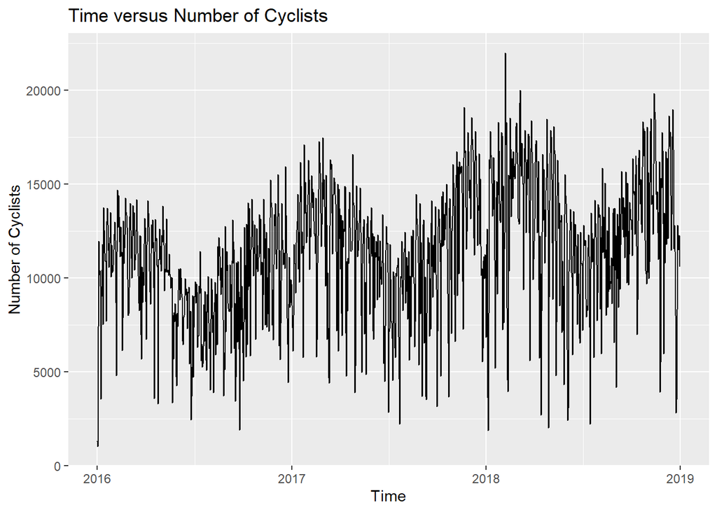

```r
#Number of cyclists verus time
ggplot(data=rainfall_cyclist_df, aes(x=timestamp, y=`Total Cyclists`)) + geom_line() +
  ggtitle("Time versus Number of Cyclists") +
  labs(y="Number of Cyclists", x = "Time")
```

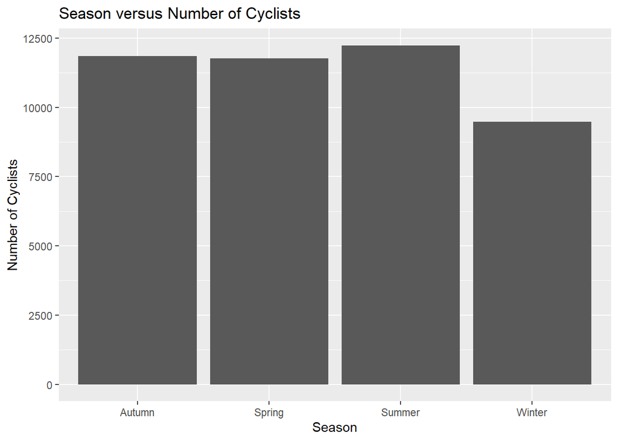

```r
#Number of cyclists over season
rainfall_cyclist_df %>%
  mutate(month.no = month(timestamp),
         season = case_when(month.no < 3 | month.no > 11 ~ "Summer",
                            month.no >= 3 & month.no < 6 ~ "Autumn",
                            month.no >= 6 & month.no < 9 ~ "Winter",
                            month.no >=9 & month.no < 12 ~ "Spring")) %>%
  group_by(season) %>%
  summarise(mean.cyclists = mean(`Total Cyclists`, na.rm=TRUE)) %>%
  ggplot(data=., aes(x=season, y=mean.cyclists)) + geom_bar(stat="identity") +
  ggtitle("Season versus Number of Cyclists") +
  labs(y="Number of Cyclists", x = "Season")
```

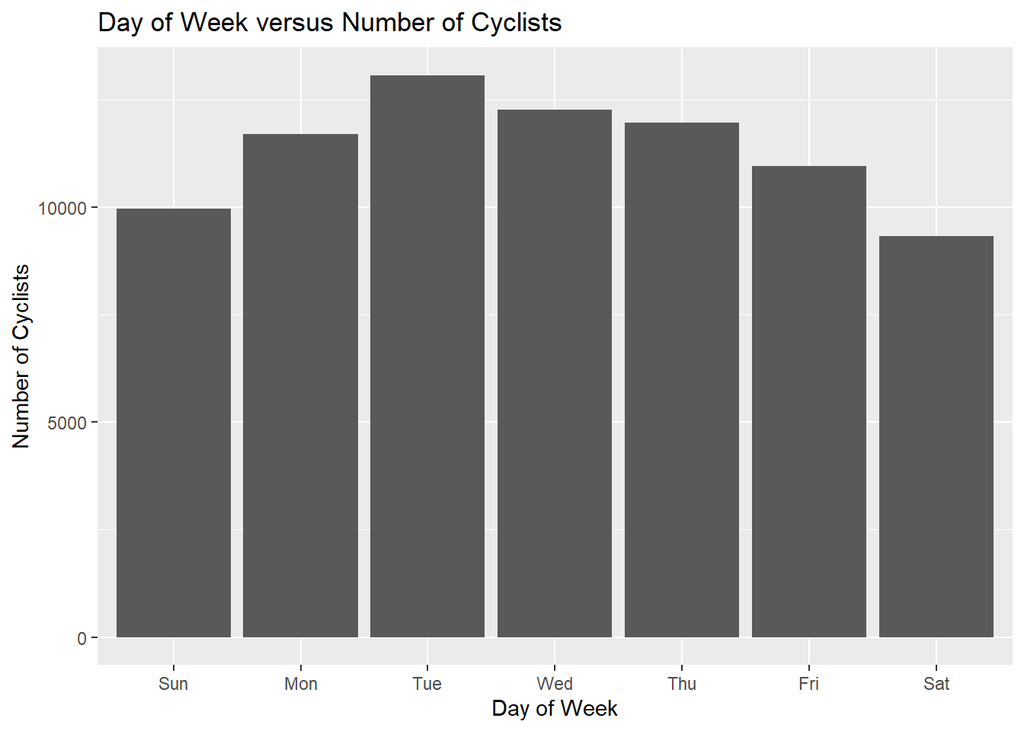

```r
#Number of cyclists versus day of the week
rainfall_cyclist_df %>%
  mutate(dow = wday(timestamp, label=TRUE)) %>%
  group_by(dow) %>%
  summarise(mean.cyclists = mean(`Total Cyclists`, na.rm=TRUE)) %>%
  ggplot(data=., aes(x=dow, y=mean.cyclists)) + geom_bar(stat="identity") +
  ggtitle("Day of Week versus Number of Cyclists") +
  labs(y="Number of Cyclists", x = "Day of Week")
```

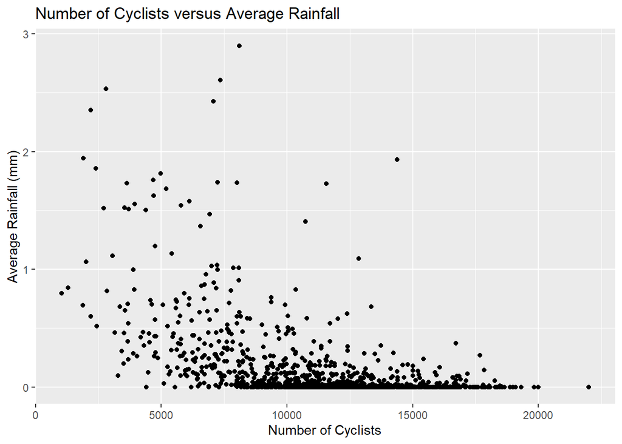

```r
#Number of cyclists varies with rain
ggplot(data=rainfall_cyclist_df, aes(x=`Total Cyclists`, y=`Mean Rainfall`)) + geom_point() +
  ggtitle("Number of Cyclists versus Average Rainfall") +
  labs(y="Average Rainfall (mm)", x = "Number of Cyclists")
```

## Question 4: Fit a regression model to predict the number of cyclists from year, season, day of the week, and rain.

This question was solved by:

First transforming the joined dataframe (from Q2) by creating month number, season, day-of-the-week and year number columns. Then fitting a simple linear model to the data.

```r
input.df = rainfall_cyclist_df %>%
  mutate(month.no = month(timestamp),
         season = factor(case_when(month.no < 3 | month.no > 11 ~ "Summer",
                            month.no >= 3 & month.no < 6 ~ "Autumn",
                            month.no >= 6 & month.no < 9 ~ "Winter",
                            month.no >=9 & month.no < 12 ~ "Spring")),
         dow = factor(wday(timestamp)),
         year.no = factor(year(timestamp))) %>%
  select(year.no, season, dow, `Mean Rainfall`, `Total Cyclists`)

cyclists.fit = lm(`Total Cyclists` ~ year.no + season + dow + `Mean Rainfall`, data=input.df)
```

## Question 5: Based on your graphs and model, does rain have a big impact on the number of people cycling in Auckland?

```r
summary(cyclists.fit)
```

```
##
## Call:
## lm(formula = `Total Cyclists` ~ year.no + season + dow + `Mean Rainfall`,
##     data = input.df)
##
## Residuals:
##      Min       1Q   Median       3Q      Max
## -10205.1  -1266.7    190.7   1351.2   9253.1
##
## Coefficients:
##                 Estimate Std. Error t value Pr(>|t|)
## (Intercept)       9810.1      229.5  42.746  < 2e-16 ***
## year.no2017       1717.7      160.8  10.684  < 2e-16 ***
## year.no2018       3107.3      161.0  19.305  < 2e-16 ***
## seasonSpring      -392.3      185.9  -2.111 0.035012 *
## seasonSummer       309.6      185.9   1.665 0.096173 .
## seasonWinter     -2361.2      185.0 -12.765  < 2e-16 ***
## dow2              1574.6      245.3   6.418 2.06e-10 ***
## dow3              2977.9      245.7  12.120  < 2e-16 ***
## dow4              2452.6      245.7   9.982  < 2e-16 ***
## dow5              2053.2      245.7   8.358  < 2e-16 ***
## dow6               860.1      245.3   3.506 0.000474 ***
## dow7              -670.7      245.3  -2.735 0.006348 **
## `Mean Rainfall`  -5395.1      197.5 -27.316  < 2e-16 ***
## ---
## Signif. codes:  0 '***' 0.001 '**' 0.01 '*' 0.05 '.' 0.1 ' ' 1
##
## Residual standard error: 2173 on 1083 degrees of freedom
## Multiple R-squared:  0.6101, Adjusted R-squared:  0.6057
## F-statistic: 141.2 on 12 and 1083 DF,  p-value: < 2.2e-16
```

```r
confint(cyclists.fit)
```

```
##                       2.5 %      97.5 %
## (Intercept)      9359.82034 10260.43964
## year.no2017      1402.25186  2033.17502
## year.no2018      2791.46260  3423.10738
## seasonSpring     -757.02427   -27.64114
## seasonSummer      -55.21789   674.35567
## seasonWinter    -2724.17254 -1998.27685
## dow2             1093.23077  2055.96216
## dow3             2495.78311  3460.03165
## dow4             1970.46061  2934.64866
## dow5             1571.14684  2535.19365
## dow6              378.70056  1341.49207
## dow7            -1151.91940  -189.44096
## `Mean Rainfall` -5782.68043 -5007.58873
```

Yes, examining the model summary output above it can be observed that we have evidence of a very strong relationship between average rainfall and the number of people cycling in Auckland. The model summary shows that as the average amount of rain (in mm) increases, the expected number of cyclists in Auckland decreases. This is as we would expect. From the confidence interval summary we estimate that for each additional millimeter of rainfall, on average, the number of cyclists in Auckland decreases by 5008 to 5783.